# プレゼミ0106

深作 輝多

更新日:2022年 1月 06日

# ライブラリの読み込み

```r
library("tidyverse")
library("stargazer")
library("skimr")
library("car")
```

# ファイルの読み込み

```r
df <- read_csv("qog_bas_ts_jan21.csv")
head(df)
```

```
## # A tibble: 6 x 260
##   ccode cname   year ccodealp cname_year  ccodealp_year ccodecow ccodewb version
##   <dbl> <chr>  <dbl> <chr>    <chr>       <chr>            <dbl>   <dbl> <chr>
## 1     4 Afgha~  1946 AFG      Afghanista~ AFG46              700       4 QoGBas~
## 2     4 Afgha~  1947 AFG      Afghanista~ AFG47              700       4 QoGBas~
## 3     4 Afgha~  1948 AFG      Afghanista~ AFG48              700       4 QoGBas~
## 4     4 Afgha~  1949 AFG      Afghanista~ AFG49              700       4 QoGBas~
## 5     4 Afgha~  1950 AFG      Afghanista~ AFG50              700       4 QoGBas~
## 6     4 Afgha~  1951 AFG      Afghanista~ AFG51              700       4 QoGBas~
## # ... with 251 more variables: ajr_settmort <dbl>, arda_bagenpct <lgl>,
## #   arda_bugenpct <lgl>, arda_chgenpct <lgl>, arda_cogenpct <lgl>,
## #   arda_higenpct <lgl>, arda_isgenpct <lgl>, arda_jagenpct <lgl>,
## #   arda_jdgenpct <lgl>, arda_norelpct <lgl>, arda_otgenpct <lgl>,
## #   arda_shgenpct <lgl>, arda_sigenpct <lgl>, arda_sygenpct <lgl>,
## #   arda_tagenpct <lgl>, arda_zogenpct <lgl>, atop_ally <dbl>,
## #   atop_number <dbl>, bci_bci <dbl>, bicc_gmi <dbl>, biu_offrel <dbl>, ...
```

# データの整形

データフレームを使う変数だけに

```r
df2 <- select(df, cname, year, wdi_broadb, wbgi_pve, wdi_acel, bci_bci, icrg_qog)
summary(df2)
```

```
##     cname                year        wdi_broadb        wbgi_pve
##  Length:15825       Min.   :1946   Min.   : 0.000   Min.   :-3.315
##  Class :character   1st Qu.:1964   1st Qu.: 0.176   1st Qu.:-0.693
##  Mode  :character   Median :1983   Median : 2.633   Median : 0.042
##                     Mean   :1983   Mean   : 8.826   Mean   :-0.048
##                     3rd Qu.:2002   3rd Qu.:14.036   3rd Qu.: 0.809
##                     Max.   :2020   Max.   :52.551   Max.   : 1.760
##                                    NA's   :12568    NA's   :11820
##     wdi_acel         bci_bci         icrg_qog
##  Min.   :  0.01   Min.   : 6.45   Min.   :0.042
##  1st Qu.: 58.70   1st Qu.:35.69   1st Qu.:0.394
##  Median : 97.85   Median :51.14   Median :0.500
##  Mean   : 77.90   Mean   :47.17   Mean   :0.545
##  3rd Qu.:100.00   3rd Qu.:58.97   3rd Qu.:0.678
##  Max.   :100.00   Max.   :74.96   Max.   :1.000
##  NA's   :11291    NA's   :10186   NA's   :10886
```

データフレームを使う年数だけに

```r
df2_2015 <- filter(df2, year == 2015)
df2_year <- filter(df2, year == 2000 | year == 2005 | year == 2010 | year == 2015 | year == 2020)
```

最近の2015年を確認する

### skimr

```r
skim(df2_2015)
```

Data summary

| Name | df2_2015 |
| --- | --- |
| Number of rows | 211 |
| Number of columns | 7 |
| _______________________ |  |
| Column type frequency: |  |
| character | 1 |
| numeric | 6 |
| ________________________ |  |
| Group variables | None |

**Variable type: character**

| skim_variable | n_missing | complete_rate | min | max | empty | n_unique | whitespace |
| --- | --- | --- | --- | --- | --- | --- | --- |
| cname | 0 | 1 | 4 | 29 | 0 | 211 | 0 |

**Variable type: numeric**

| skim_variable | n_missing | complete_rate | mean | sd | p0 | p25 | p50 | p75 | p100 | hist |
| --- | --- | --- | --- | --- | --- | --- | --- | --- | --- | --- |
| year | 0 | 1.00 | 2015.00 | 0.00 | 2015.00 | 2015.00 | 2015.00 | 2015.00 | 2015.00 | ▁▁▇▁▁ |
| wdi_broadb | 20 | 0.91 | 12.01 | 13.18 | 0.00 | 0.58 | 6.67 | 20.81 | 48.66 | ▇▂▂▂▁ |
| wbgi_pve | 17 | 0.92 | -0.07 | 0.98 | -2.97 | -0.63 | 0.02 | 0.76 | 1.53 | ▁▂▇▇▇ |
| wdi_acel | 18 | 0.91 | 81.74 | 27.46 | 7.70 | 67.28 | 99.30 | 100.00 | 100.00 | ▁▁▁▁▇ |
| bci_bci | 19 | 0.91 | 47.00 | 16.36 | 7.24 | 36.56 | 50.73 | 58.93 | 74.66 | ▂▃▅▇▅ |
| icrg_qog | 72 | 0.66 | 0.53 | 0.21 | 0.08 | 0.39 | 0.47 | 0.67 | 0.97 | ▂▇▇▃▃ |

## 散布図

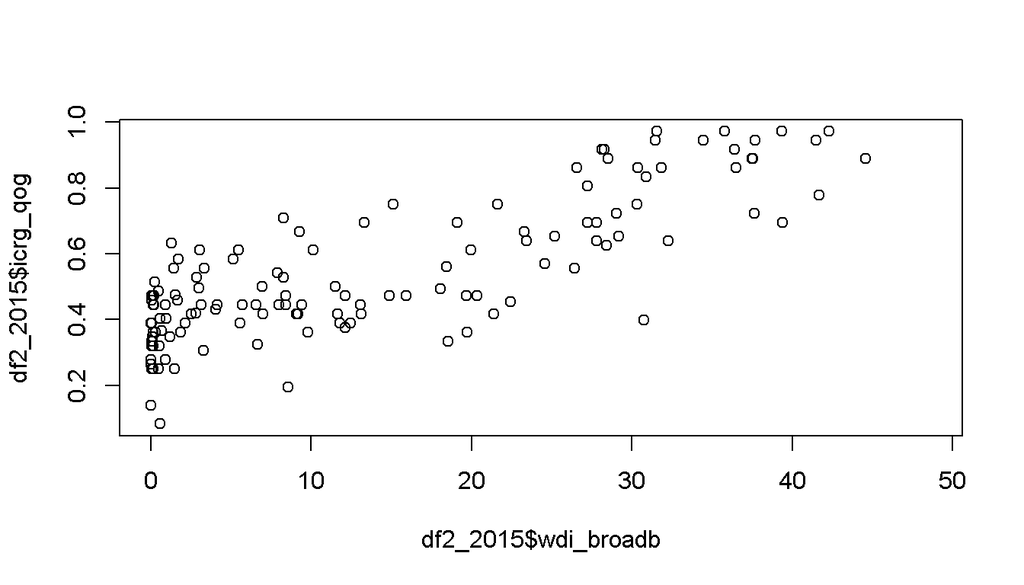

```r
plot(df2_2015$wdi_broadb, df2_2015$icrg_qog)
```

```r
cor(df2_2015$wdi_broadb, df2_2015$icrg_qog, use = "complete.obs")
```

```
## [1] 0.8124789
```

2015年では強い相関がある。一方で時間的先行の問題もあるので、ここからbroadbの値が年々どのように変化したのかを見る。

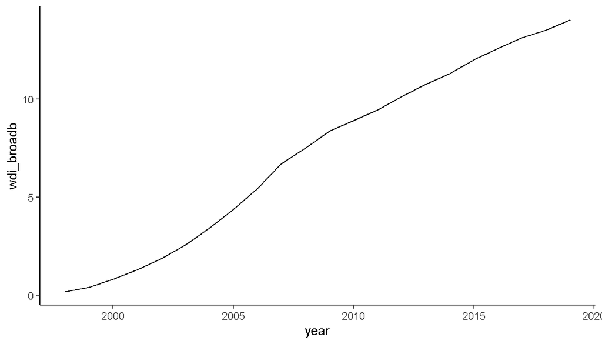

```r
bar_broadb <- aggregate(wdi_broadb ~ year, data = df, FUN = mean)
gbroad <- ggplot(data = bar_broadb, aes(x = year, y = wdi_broadb)) +
  geom_line() +
  theme_classic()
gbroad
```

年ごとに散布図がどんな形をしているのか確認しよう

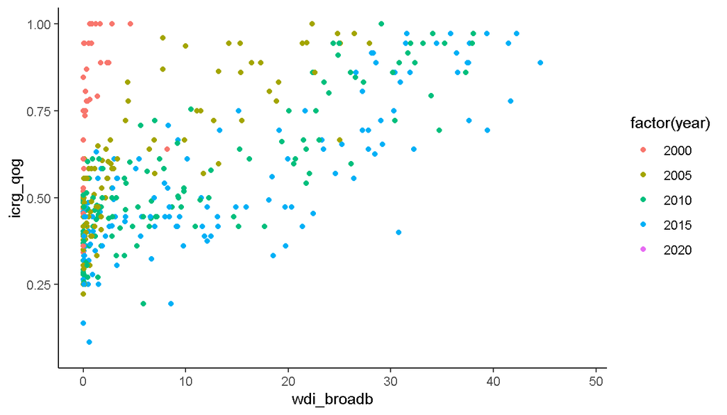

```r
g01 <- ggplot(df2_year, aes(wdi_broadb, icrg_qog, color = factor(year))) +
  geom_point() +
  theme_classic()
g01
```

2005年から国ごとの差異が現われている。

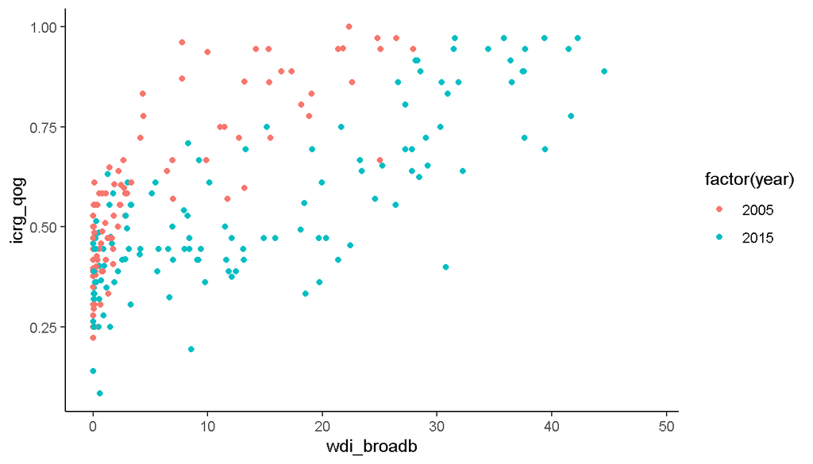

```r
df2_0015 <- filter(df2, year == 2005 | year == 2015)
g02 <- ggplot(df2_0015, aes(wdi_broadb, icrg_qog, color = factor(year))) +
  geom_point() +
  theme_classic()
g02
```

```r
df2_2005 <- filter(df2, year == 2005)
df2_2015 <- filter(df2, year == 2015)
```

# 回帰分析

（原因と結果を同年）

```r
ols1_1 <- lm(df2_2015$icrg_qog ~ df2_2015$wdi_broadb)
ols2_1 <- update(ols1_1, ~ . + df2_2015$bci_bci)
ols3_1 <- update(ols2_1, ~ . + df2_2015$wdi_acel)
```

（原因を結果の10年前）

```r
ols1_2 <- lm(df2_2015$icrg_qog ~ df2_2005$wdi_broadb)
ols2_2 <- update(ols1_2, ~ . + df2_2005$bci_bci)
ols3_2 <- update(ols2_2, ~ . + df2_2005$wdi_acel)
```

## 回帰分析の出力

```r
library(stargazer)
stargazer(ols1_1, ols2_1, ols3_1, ols1_2, ols2_2, ols3_2,
  type = "text",
  keep.stat = c("n", "adj.rsq", "f"),
  df = FALSE
)
```

```
##
## ==============================================================================
##                                     Dependent variable:
##              -----------------------------------------------------------------
##                                          icrg_qog
##                 (1)        (2)        (3)        (4)        (5)        (6)
## ------------------------------------------------------------------------------
## wdi_broadb    0.013***   0.006***   0.006***
##               (0.001)    (0.001)    (0.001)
##
## bci_bci                 -0.008***  -0.008***
##                          (0.001)    (0.001)
##
## wdi_acel                             0.0002
##                                     (0.0003)
##
## wdi_broadb                                     0.022***   0.009***   0.008***
##                                                (0.001)    (0.001)    (0.001)
##
## bci_bci                                                  -0.008***  -0.008***
##                                                           (0.001)    (0.001)
##
## wdi_acel                                                              0.0004
##                                                                      (0.0003)
##
## Constant      0.363***   0.812***   0.799***   0.465***   0.881***   0.843***
##               (0.015)    (0.037)    (0.045)    (0.013)    (0.035)    (0.048)
##
## ------------------------------------------------------------------------------
## Observations    136        136        136        116        116        112
## Adjusted R2    0.658      0.842      0.841      0.673      0.857      0.857
## F Statistic  260.259*** 360.552*** 239.119*** 237.862*** 346.095*** 222.940***
## ==============================================================================
## Note:                                              *p<0.1; **p<0.05; ***p<0.01
```

結果の解釈

独立と従属は同年でも、10年前でも同じく有意な結果である。

その一方で係数を見ると wdi_broadbが1増えるとicrg_qogが0.008増える。 それぞれの値域がwdi_broadbは0から48.66、icrg_qogは0から1であるので wdi_broadbが1%(=0.4866)増えるとicrg_qogが0.39%(=0.4866×0.008×100)増える。

固定ブロードバンド契約数(100人あたり)(wdi_broadb)

ICRG「政府の質」の指標（icrg_qog）

ICRG変数Corruption, Law and Order, Bureaucracy Qualityの平均値を0から1の範囲で設定する。値が高いほど、政府の質が高いことを示す。